# Analyzing LDL Cholesterol and HBP Medication

# 1 Setup and Data Ingest

## 1.1 Initial Setup and Package Loads

In this section, we load the packages that we will use for study 1.

```r
library(knitr); library(rmdformats)

library(janitor); library(naniar)
library(broom); library(patchwork)

library(nhanesA)

library(car)
library(readxl)
library(Epi)
library(Hmisc)
library(tidyverse)

## Global options
opts_chunk$set(comment=NA)
opts_knit$set(width=75)

theme_set(theme_bw())
```

## 1.2 Loading the Raw Data into R

Here, we import our data to keep the necessary variables needed as well as merge the separate datasets together to create one dataset that we will use for the study.

```r
# raw data
ldl <- nhanes('P_TRIGLY') |> tibble() |> clean_names()
demo <- nhanes('P_DEMO') |> tibble() |> clean_names()
blood <- nhanes('P_BPQ') |> tibble() |> clean_names()

# get needed data and filter out those
ldl <- ldl |> select(seqn, lbdldl)
demo <- demo |> select(seqn, riagendr, ridreth3, ridstatr, ridageyr)
blood <- blood |> select(seqn, bpq050a)

# join data
new <- inner_join(ldl, demo, by = "seqn")
study1 <- inner_join(new, blood, by = "seqn")

# see if all seqn values are unique
dim(study1)
```

```
[1] 4654    7
```

```r
length(unique(study1$seqn))
```

```
[1] 4654
```

# 2 Cleaning the Data

We now want to begin filtering our data. We will filter `ridstatr` and `ridageyr` to only keep adult subjects that were both interviewed and MEC examined. Next we keep only those observations with complete cases as we can assume that the observations are missing values completely at random. Lastly, we change values for `riagendr` and `bpq050a` as well as make `ridreth3` a factor.

```r
# filter out those with missing values
study1 <- study1 |> filter(complete.cases(study1))

# filter adults and only keep ridstatr values of 2
study1 <- study1 |>
  filter(ridstatr == 2) |>
  filter(ridageyr >= 21) |>
  filter(ridageyr < 80)

# check that all ridstatr values are 2
unique(study1$ridstatr)
```

```
[1] 2
```

```r
# filter complete cases
study1 <- study1 |> filter(complete.cases(study1))

# make variables factors
study1 <- study1 |>
  mutate(riagendr = replace(riagendr, riagendr == 2, 0)) |>
  mutate(riagendr = factor(riagendr))

study1 <- study1 |>
  mutate(bpq050a = replace(bpq050a, bpq050a == 2, 0)) |>
  mutate(bpq050a = factor(bpq050a))

study1 <- study1 |> mutate(ridreth3 = factor(ridreth3))

study1 <- study1 |>
  select(seqn, lbdldl, riagendr, ridreth3, bpq050a)

study1
```

```
# A tibble: 1,252 × 5
     seqn lbdldl riagendr ridreth3 bpq050a
    <dbl>  <dbl> <fct>    <fct>    <fct>
 1 109274     49 1        7        1
 2 109282    164 1        3        1
 3 109290    105 0        4        1
 4 109292    102 1        2        1
 5 109322    101 0        1        0
 6 109324    108 0        3        1
 7 109330     67 1        6        1
 8 109335    109 0        4        1
 9 109371    133 1        6        1
10 109379    102 0        3        1
# … with 1,242 more rows
```

We can now see our resulting dataset that we will use for study 1.

## 2.1 Quantitative Variable Check

Now we will check our outcome variable `lbdldl` and get a numeric summary.

```r
mosaic::favstats(study1$lbdldl)
```

```
 min Q1 median  Q3 max     mean       sd    n missing
   7 79    101 129 357 105.6438 37.74767 1252       0
```

From this summary, we can see that the median value is close to the median, so the value distribution is likely pretty symmetric.

## 2.2 Binary Variables Check

We will also check numerical summaries for our binary variables, `riagendr` and `bpq050a`, to see their value distributions.

```r
study1 |> select(riagendr,bpq050a) |> summary()
```

```
 riagendr bpq050a
 0:655    0: 207
 1:597    1:1045
```

For `riagendr`, we can see that the value distribution is quite balanced while for `bpq050a`, the distribution is very imbalanced.

## 2.3 Multicategorical Variables Check

Lastly, we will check our multicategorical variable `ridreth3` to see its value distributions.

```r
study1 |> select(ridreth3) |> summary()
```

```
 ridreth3
 1:112
 2:133
 3:382
 4:435
 6:128
 7: 62
```

We can see that not all of the groups are evenly distributed, with the number of observations for each group ranging from 62-435.

## 2.4 List of Missing Values

We can now count the number of missing observations in each variable, which should be 0 for all of them since we filtered out complete cases earlier.

```r
miss_var_summary(study1)
```

```
# A tibble: 5 × 3
  variable n_miss pct_miss
  <chr>     <int>    <dbl>
1 seqn          0        0
2 lbdldl        0        0
3 riagendr      0        0
4 ridreth3      0        0
5 bpq050a       0        0
```

As expected, we have no missing values in our dataset.

# 3 Codebook and Data Description

## 3.1 Codebook

The NHANES dataset combines interviews and physical examinations from adults and children in the United States using surveys examining a nationally representative sample of about 5,000 persons each year. In my work, we used data from the 2017 - March 2020 survey period, and from the following data sets: Demographics (P-DEMO), LDL Cholesterol (P-TRIGLY), and Blood Pressure and Cholesterol (P-BPQ). We also restricted the data to adults between 21-79 as we don’t want to include children or the elderly.

The 5 variables in our tidy data set `study1` are `seqn`, `lbdldl`, `riagendr`, `ridreth3`, `bpq050a`. The ‘Type’ column indicates the number of levels in each categorical (factor) variable. For the Type information, ‘Quantitative’ represents a quantitative variable and ‘Categorical (x)’ indicates a categorical variable with x levels.

| Variable | Type | Description / Levels |
| --- | --- | --- |
| `seqn` | ID | Subject code identifier of patient |
| `lbdldl` | Quantitative | Patient’s LDL-cholesterol (mg/dL) |
| `riagendr` | Categorical (2) | Gender of patient: 0 if female, 1 if male |
| `ridreth3` | Categorical (6) | The race/Hispanic origin of a patient with NH Asian: 1 if Mexican American, 2 if Other Hispanic, 3 if Non-Hispanic White, 4 if Non-Hispanic Black, 6 if Non-Hispanic Asian, 7 if Other Race - Including … |
| `bpq050a` | Categorical (2) | If patient is taking prescribed medicine for high blood pressure: 0 if no, 1 if yes |

## 3.2 Analytic Tibble

We will now prove that `study1` is a tibble by printing it.

```r
is_tibble(study1)
```

```
[1] TRUE
```

```r
study1
```

```
# A tibble: 1,252 × 5
     seqn lbdldl riagendr ridreth3 bpq050a
    <dbl>  <dbl> <fct>    <fct>    <fct>
 1 109274     49 1        7        1
 2 109282    164 1        3        1
 3 109290    105 0        4        1
 4 109292    102 1        2        1
 5 109322    101 0        1        0
 6 109324    108 0        3        1
 7 109330     67 1        6        1
 8 109335    109 0        4        1
 9 109371    133 1        6        1
10 109379    102 0        3        1
# … with 1,242 more rows
```

## 3.3 Data Summary

We will now use describe() to get some information about each variable in our dataset.

```r
describe(study1)
```

```
study1

 5  Variables      1252  Observations
--------------------------------------------------------------------------------
seqn
       n  missing distinct     Info     Mean      Gmd      .05      .10
    1252        0     1252        1   117292     5223   110247   110958
     .25      .50      .75      .90      .95
  113366   117319   121312   123411   124052

lowest : 109274 109282 109290 109292 109322, highest: 124745 124778 124803 124810 124821
--------------------------------------------------------------------------------
lbdldl
       n  missing distinct     Info     Mean      Gmd      .05      .10
    1252        0      174        1    105.6    41.51       52       61
     .25      .50      .75      .90      .95
      79      101      129      154      170

lowest :   7  25  30  32  33, highest: 226 236 255 354 357
--------------------------------------------------------------------------------
riagendr
       n  missing distinct
    1252        0        2

Value          0     1
Frequency    655   597
Proportion 0.523 0.477
--------------------------------------------------------------------------------
ridreth3
       n  missing distinct
    1252        0        6

lowest : 1 2 3 4 6, highest: 2 3 4 6 7

Value          1     2     3     4     6     7
Frequency    112   133   382   435   128    62
Proportion 0.089 0.106 0.305 0.347 0.102 0.050
--------------------------------------------------------------------------------
bpq050a
       n  missing distinct
    1252        0        2

Value          0     1
Frequency    207  1045
Proportion 0.165 0.835
--------------------------------------------------------------------------------
```

With this, we can see the value distributions for each, as well as the lowest and highest values of quantitative variables and level frequency and proportions for categorical variables.

# 4 Analysis B: Compare 2 Population Means using Independent Samples

## 4.1 The Question

In this analysis, we will compare `lbdldl` by `riagendr` using independent samples. We’re comparing the mean `lbdldl` of the population represented by respondents who are male to the mean `lbdldl` of the population represented by the respondents who are female. There is nothing to suggest that the two samples of male `lbdldl` and female `lbdldl` values are paired or matched in any way. With this, we’re going to investigate the two samples independently to help us understand issues related to hypothesis testing assumptions.

Our research question is:

Is there a meaningful difference between male and female patients in their ‘bad’ LDL cholesterol values?

## 4.2 Describing the Data

We will begin by making our gender variable (`riagendr`) more descriptive and examining a breakdown of `lbdldl` values by patients’ gender.

```r
b_data <- study1 |>
  mutate(riagendr_b = fct_recode(factor(riagendr),
                                 "Male" = "1",
                                 "Female" = "0"))

mosaic::favstats(lbdldl ~ riagendr_b, data = b_data) |>
  kable(digits = 2)
```

| riagendr_b | min | Q1 | median | Q3 | max | mean | sd | n | missing |
| --- | --- | --- | --- | --- | --- | --- | --- | --- | --- |
| Female | 25 | 83 | 107 | 133 | 357 | 110.36 | 39.12 | 655 | 0 |
| Male | 7 | 74 | 97 | 124 | 222 | 100.47 | 35.50 | 597 | 0 |

From this preliminary summary breakdown, we can see that female patients appear to have a higher mean and median `lbdldl` than male patients. Similarly, all of females’ quartile values are higher as well as their standard deviation.

We also want to confirm that there are at least 15 unique values for our outcome variable and that each gender subgroup has at least 30 patients using tabyl().

```r
length(unique(b_data$lbdldl))
```

```
[1] 174
```

```r
b_data |> tabyl(riagendr_b)
```

```
 riagendr_b   n   percent
     Female 655 0.5231629
       Male 597 0.4768371
```

From this, we can see that both ‘Female’ and ‘Male’ have at least 30 values.

### 4.2.1 Graphical Summaries

We will create a data visualizations to see how our outcome variable `lbdldl` is distributed between males and females.

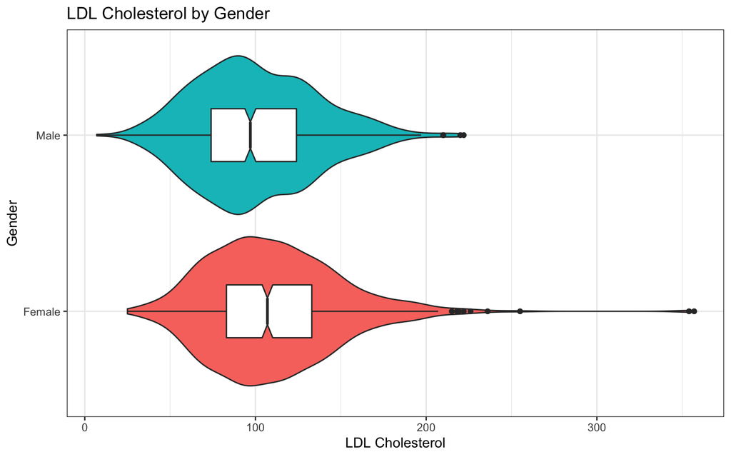

```r
ggplot(b_data, aes(x = riagendr_b, y = lbdldl)) +
  geom_violin(aes(fill = riagendr_b)) +
  geom_boxplot(width = 0.3, notch = TRUE) +
  guides(fill = "none") +
  coord_flip() +
  labs(title = "LDL Cholesterol by Gender",
       x = "Gender", y = "LDL Cholesterol") +
  coord_flip() +
  theme_bw()
```

We can see that both of these groups, the cholesterol distribution is somewhat skewed right, particularly for female patients who also has a handful of outliers. Next, we will look at the normality of `lbdldl` for each gender.

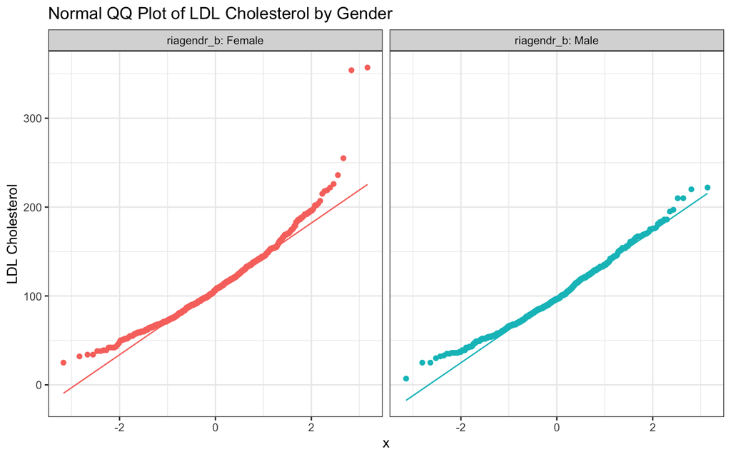

```r
ggplot(b_data, aes(sample = lbdldl, col = riagendr_b)) +
  geom_qq() +
  geom_qq_line() +
  facet_wrap(~ riagendr_b, labeller = "label_both") +
  guides(col = "none") +
  theme_bw() +
  labs(y = "LDL Cholesterol",
       title = "Normal QQ Plot of LDL Cholesterol by Gender")
```

These QQ plots for each gender confirms that both groups have a right skew, with female patients having a clear skew and male patients being slightly skewed.

### 4.2.2 Outcome Normalization

With the right skew we saw of `lbdldl`, we will use a Box-Cox model to see if there’s a transformation for `lbdldl` that may effectively normalize the values.

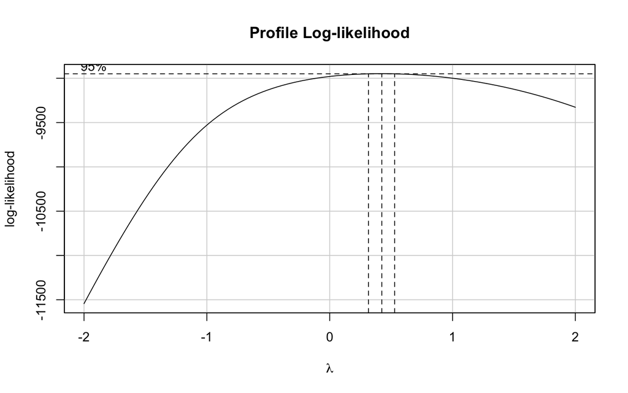

```r
boxCoxMod <- lm(lbdldl ~ riagendr_b, data = b_data)
boxCox(boxCoxMod)
```

From the model, it appears that a square root transformation of LDL cholesterol values may normalize the distribution. To check, we will replot the QQ plot split by gender.

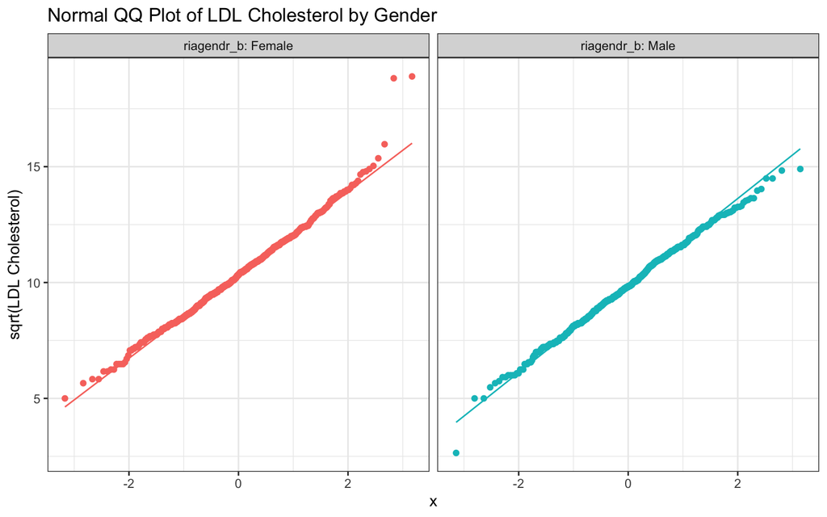

```r
ggplot(b_data, aes(sample = sqrt(lbdldl), col = riagendr_b)) +
  geom_qq() +
  geom_qq_line() +
  facet_wrap(~ riagendr_b, labeller = "label_both") +
  guides(col = "none") +
  theme_bw() +
  labs(y = "sqrt(LDL Cholesterol)",
       title = "Normal QQ Plot of LDL Cholesterol by Gender")
```

As we can see from the new QQ plots, the square root transformation has effectively normalized `lbdldl` values for each gender.

## 4.3 Main Analysis

Before we begin our analysis, we will check the raw mean and variance values of `lbdldl` for each gender.

```r
b_data |> group_by(riagendr_b) |>
  summarise(n = n(), mean = mean(lbdldl), variance = var(lbdldl))
```

```
# A tibble: 2 × 4
  riagendr_b     n  mean variance
  <fct>      <int> <dbl>    <dbl>
1 Female       655  110.    1531.
2 Male         597  100.    1260.
```

This summary shows us that the mean `lbdldl` for females is greater than males and the variance of females is much higher than of males.

### 4.3.1 Welch’s t-test

With our transformation of the outcome variable, we can assume normality of `lbdldl` values. From our numerical summaries between male and female patients, we can also see that their variance are not very similar. Because of this, we will use a Welch’s t-test to compare the means of `lbdldl` values between gender, as we can also assume that the samples in each group are randomly and independently drawn and that the samples in each group represent a sample of the population of interest.

```r
t.test(sqrt(lbdldl) ~ riagendr_b, data = b_data, conf.level = 0.90)
```

```
    Welch Two Sample t-test

data:  sqrt(lbdldl) by riagendr_b
t = 4.7586, df = 1240.9, p-value = 2.178e-06
alternative hypothesis: true difference in means between group Female and group Male is not equal to 0
90 percent confidence interval:
 0.3182735 0.6549141
sample estimates:
mean in group Female   mean in group Male
           10.347458             9.860864
```

## 4.4 Conclusions

From our Welch’s t-test, we found a 90% confidence interval describing the difference in population means of the square root `lbdldl` values for male and female patients. From this interval of (0.32, 0.65), we can see that 0 is not included which indicates with 90% confidence that the difference in mean values of male and female `lbdldl` is not 0. If it was 0, it would mean that the means of both groups are the same, so by 0 not being included, we can find with 90% confidence that female patients have higher LDL cholesterol values than men based on our sample of patients. The p-value is also below our 90% confidence threshold of 0.10, so our result is statistically significant.

# 5 Analysis C: Comparing 6 Population Means

## 5.1 The Question

For this analysis, we are comparing `lbdldl` by `ridreth3`, which indicates the race/Hispanic origin of patient. To do so, we will use analysis of variance (ANOVA) and related tools to compare the mean `lbdldl` values of the population based on different race origins. There are 6 values in `ridreth3`: 1 if Mexican American, 2 if Other Hispanic, 3 if Non-Hispanic White, 4 if Non-Hispanic Black, 6 if Non-Hispanic Asian, 7 if Other Race - Including Multi-Racial. There isn’t any crossover/relationship between the groups, so the samples are independent.

Our research question is:

Are there statistically meaningful differences in `lbdldl` values between patients with various race origins and if so, is it consistent with previous scientific studies?

## 5.2 Describing the Data

We will begin by giving `ridreth3` more descriptive values and seeing a numerical summary of `lbdldl` values broken down by each race group.

```r
c_data <- study1 |>
  mutate(ridreth3_c = fct_recode(factor(ridreth3),
                                 "Mexican American" = "1",
                                 "Other Hispanic" = "2",
                                 "Non-Hispanic White" = "3",
                                 "Non-Hispanic Black" = "4",
                                 "Non-Hispanic Asian" = "6",
                                 "Other Race" = "7"))

mosaic::favstats(lbdldl ~ ridreth3_c, data = c_data)
```

```
          ridreth3_c min    Q1 median     Q3 max     mean       sd   n missing
1   Mexican American  30 81.00  104.0 124.25 197 105.6250 35.95721 112       0
2     Other Hispanic  36 80.00  109.0 126.00 218 106.3985 34.24310 133       0
3 Non-Hispanic White   7 77.00   98.0 128.00 354 103.3168 37.20083 382       0
4 Non-Hispanic Black  25 79.50   99.0 127.00 357 105.9494 39.38142 435       0
5 Non-Hispanic Asian  34 84.75  112.0 135.75 255 112.7344 39.39353 128       0
6         Other Race  25 76.75  102.5 128.50 175 101.6129 35.56769  62       0
```

Each group has at least 30 observations, so we don’t have to consider collapsing any groups together. We can also see that Non-Hispanic White and Non-Hispanic Black appears to have lower center `lbdldl` values, while Non-Hispanic Asian appears to have higher center values.

### 5.2.1 Graphical Summaries

We will now visualize our data through box and violin plots.

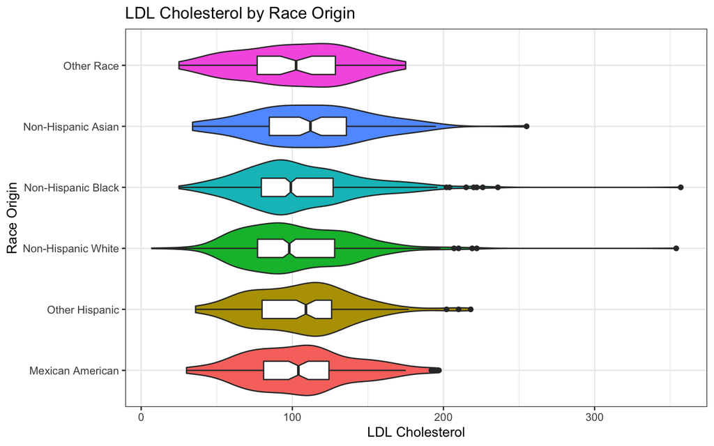

```r
ggplot(c_data, aes(x = ridreth3_c, y = lbdldl)) +
  geom_violin(aes(fill = ridreth3_c)) +
  geom_boxplot(width = 0.3, notch = TRUE) +
  guides(fill = "none") +
  coord_flip() +
  labs(title = "LDL Cholesterol by Race Origin",
       x = "Race Origin", y = "LDL Cholesterol") +
  coord_flip() +
  theme_bw()
```

From this plot, we can see that most of the groups are pretty normally distributed with some outliers. The groups that aren’t are Non-Hispanic White and Non-Hispanic Black, which appear to be skewed right.

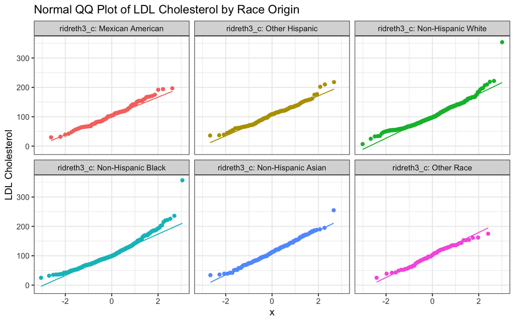

```r
ggplot(c_data, aes(sample = lbdldl, col = ridreth3_c)) +
  geom_qq() +
  geom_qq_line() +
  facet_wrap(~ ridreth3_c, labeller = "label_both") +
  guides(col = "none") +
  theme_bw() +
  labs(y = "LDL Cholesterol",
       title = "Normal QQ Plot of LDL Cholesterol by Race Origin")
```

Because we are analyzing the distributions of six independent sample groups, we looked at the normality of values more for each group. As seen before, Non-Hispanic White and Non-Hispanic Black are skewed right while the other groups look normally distributed.

### 5.2.2 Numerical Summaries

Again, we will look at numeric summaries of `lbdldl` for each group.

```r
mosaic::favstats(lbdldl ~ ridreth3_c, data = c_data) |>
  kable()
```

| ridreth3_c | min | Q1 | median | Q3 | max | mean | sd | n | missing |
| --- | --- | --- | --- | --- | --- | --- | --- | --- | --- |
| Mexican American | 30 | 81.00 | 104.0 | 124.25 | 197 | 105.6250 | 35.95721 | 112 | 0 |
| Other Hispanic | 36 | 80.00 | 109.0 | 126.00 | 218 | 106.3985 | 34.24310 | 133 | 0 |
| Non-Hispanic White | 7 | 77.00 | 98.0 | 128.00 | 354 | 103.3168 | 37.20083 | 382 | 0 |
| Non-Hispanic Black | 25 | 79.50 | 99.0 | 127.00 | 357 | 105.9494 | 39.38142 | 435 | 0 |
| Non-Hispanic Asian | 34 | 84.75 | 112.0 | 135.75 | 255 | 112.7344 | 39.39353 | 128 | 0 |
| Other Race | 25 | 76.75 | 102.5 | 128.50 | 175 | 101.6129 | 35.56769 | 62 | 0 |

From this numeric summary, we can see that Non-Hispanic Asian appears to have the highest `lbdldl` values in terms of mean and median. Other Race appears to have the lowest values based on mean, while Non-Hispanic White has the lowest values based on median. We can also see that the variances of all the groups are not equal as the standard deviations of the groups range from 34.24 to 39.39.

## 5.3 Main Analysis

### 5.3.1 Kruskal-Wallis Test

From our visualizations and numeric summary, we can conclude that we should use a Kruskal-Wallis test. This is because all of the ANOVA assumptions aren’t met with our data, which does satisfy the assumption of independently obtained samples. However, two of them are not satisfied, which are equal variance of `lbdldl` in each group as well as normal distributions of `lbdldl` in each group.

```r
kruskal.test(lbdldl ~ ridreth3_c, data = c_data)
```

```
    Kruskal-Wallis rank sum test

data:  lbdldl by ridreth3_c
Kruskal-Wallis chi-squared = 7.698, df = 5, p-value = 0.1737
```

By running the Kruskal-Wallis rank sum test, we are able to obtain the test’s $\chi^2$ statistic as well as the p-value. As we can see, the p-value is 0.174, which is not below our threshold of 0.10.

## 5.4 Conclusions

We can conclude with 90% confidence that the mean `lbdldl` values of patients by race origin in our data are not statistically different based on the Kruskal-Wallis rank sum test. From the test, we got a p-value of 0.174, which is higher than our cutoff significance value of 0.10. This means that we can’t reject our null hypothesis that the mean `lbdldl` values of all six race groups are the same. With this, we can say with 90% confidence that the mean LDL cholesterol values of various race origin groups are statistically similar.

# 6 Analysis D: Two-Way (2 x 2) Contingency Table

## 6.1 The Question

In this analysis, we will investigate the association between `riagendr` and `bpq050a`. Both of these variables are binary and have two categories. For `riagendr`, 0 represents female and 1 represents male. For `bpq050a`, 0 for represents not taking taking prescribed medication for high blood pressure while 1 represents taking prescribed medication for high blood pressure.

Our research question is:

From before, we saw that females in our data seems to have higher `lbdldl` values than males. With that, does there appear to be an association between a patient’s gender and whether or not they are taking prescribed medication for high blood pressure?

## 6.2 Describing the Data

We will begin by giving `riagendr` and `bpq050a` more descriptive values and then looking at their value distributions.

```r
binary_data <- study1 |>
  select(seqn, riagendr, bpq050a) |>
  mutate(riagendr_b = fct_recode(factor(riagendr),
                                "Male" = "1",
                                "Female" = "0"),
         riagendr_b = fct_relevel(riagendr_b, "Male"),
         bpq050a_b = fct_recode(factor(bpq050a),
                                 "Not Taking HBP Medication" = "0",
                                 "Taking HBP Medication" = "1"),
         bpq050a_b = fct_relevel(bpq050a_b, "Taking HBP Medication"))

binary_data |> tabyl(riagendr_b, bpq050a_b)
```

```
 riagendr_b Taking HBP Medication Not Taking HBP Medication
       Male                   491                       106
     Female                   554                       101
```

From this tabyl, we can see that for each of the outcome categories (whether or not a patient is taking HBP medication), the values are pretty similar between male and female patients.

## 6.3 Main Analysis

We will use a Bayesian augmentation on our data that we will run with twoby2() to get various metrics.

```r
binary_augmented <- table(binary_data$riagendr_b, binary_data$bpq050a_b)

twoby2(binary_augmented + 2, conf.level = 0.90)
```

```
2 by 2 table analysis:
------------------------------------------------------
Outcome   : Taking HBP Medication
Comparing : Male vs. Female

       Taking HBP Medication Not Taking HBP Medication
Male                     493                       108
Female                   556                       103
          P(Taking HBP Medication) 90% conf. interval
Male                        0.8203    0.7931   0.8446
Female                      0.8437    0.8190   0.8656

                                    90% conf. interval
             Relative Risk:  0.9723    0.9325   1.0138
         Sample Odds Ratio:  0.8456    0.6597   1.0840
Conditional MLE Odds Ratio:  0.8458    0.6524   1.0962
    Probability difference: -0.0234   -0.0583   0.0112

             Exact P-value: 0.2904
        Asymptotic P-value: 0.2668
------------------------------------------------------
```

By doing a Bayesian augmentation, we can make conclusions about the individual probabilities, relative risk, odds ratio, and difference in probability values of taking prescribed high blood pressure medication by gender. We can also make conclusions from a chi square test of independence.

### 6.3.1 Checking Assumptions

Each cell of our table prior to the Bayesian augmentation had values that were at least 10, so we had no issues with running a twoby2 test on the table.

# 7 Analysis E: Two-Way (6 x 2) Contingency Table

## 7.1 The Question

In this analysis, we investigate the association between a patient’s race origin (`ridreth3`) and whether or not they are taking medication for high blood pressure (`bpq050a`). There are six values in `ridreth3`: 1 if Mexican American, 2 if Other Hispanic, 3 if Non-Hispanic White, 4 if Non-Hispanic Black, 6 if Non-Hispanic Asian, 7 if Other Race - Including Multi-Racial. For `bpq050a`, 0 represents not taking taking prescribed medication for high blood pressure while 1 represents taking prescribed medication for high blood pressure.

Our research question is:

Is there a statistically significant association between a patient’s race origin and whether or not they are taking prescribed medication for high blood pressure?

## 7.2 Describing the Data and Checking Assumptions

We will begin by giving `ridreth3` and `bpq050a` more descriptive values and then getting a table of expected values.

```r
e_data <- study1 |>
  mutate(ridreth3_e = fct_recode(factor(ridreth3),
                                 "Mexican American" = "1",
                                 "Other Hispanic" = "2",
                                 "Non-Hispanic White" = "3",
                                 "Non-Hispanic Black" = "4",
                                 "Non-Hispanic Asian" = "6",
                                 "Other Race" = "7")) |>
  mutate(bpq050a_e = fct_recode(factor(bpq050a),
                                "Not Taking HBP Medication" = "0",
                                "Taking HBP Medication" = "1"))

jk_table <- table(e_data$ridreth3_e, e_data$bpq050a_e)

jk_table
```

```
                     Not Taking HBP Medication Taking HBP Medication
  Mexican American                          19                    93
  Other Hispanic                            21                   112
  Non-Hispanic White                        65                   317
  Non-Hispanic Black                        73                   362
  Non-Hispanic Asian                        15                   113
  Other Race                                14                    48
```

```r
check <- e_data |>
  tabyl(ridreth3_e, bpq050a_e) |>
  chisq.test()

expected <- check$expected

expected
```

```
         ridreth3_e Not Taking HBP Medication Taking HBP Medication
   Mexican American                  18.51757              93.48243
     Other Hispanic                  21.98962             111.01038
 Non-Hispanic White                  63.15815             318.84185
 Non-Hispanic Black                  71.92093             363.07907
 Non-Hispanic Asian                  21.16294             106.83706
         Other Race                  10.25080              51.74920
```

Here, we create a 6 by 2 table that breaks down whether or not a patient takes high blood pressure medication by their race origin. We also check the expected values for each cell so that we can make sure that chi square assumptions are met. The assumptions are that each cell’s expected frequency is at least 5, each cell has no zero counts, and that at least 80% of the cells have expected values of at least 5.

## 7.3 Main Analysis

### 7.3.1 Running the Pearson $\chi^2$ Test

By referring to the expected value table, we can see that all the assumptions are satisfied, which means that we can use a $\chi^2$ test.

```r
chisq.test(jk_table)
```

```
    Pearson's Chi-squared test

data:  jk_table
X-squared = 3.9453, df = 5, p-value = 0.5573
```

Since all the conditions of the Pearson’s $\chi^2$ test are met, we run a $\chi^2$ test on our table data. We can see that the $\chi^2$ value from the test is 3.95 and the p-value is 0.56, which is much higher than our threshold of 0.10 from our 90% confidence.

### 7.3.2 Association Plot

We can also create an association plot to compare values between observed and expected values.

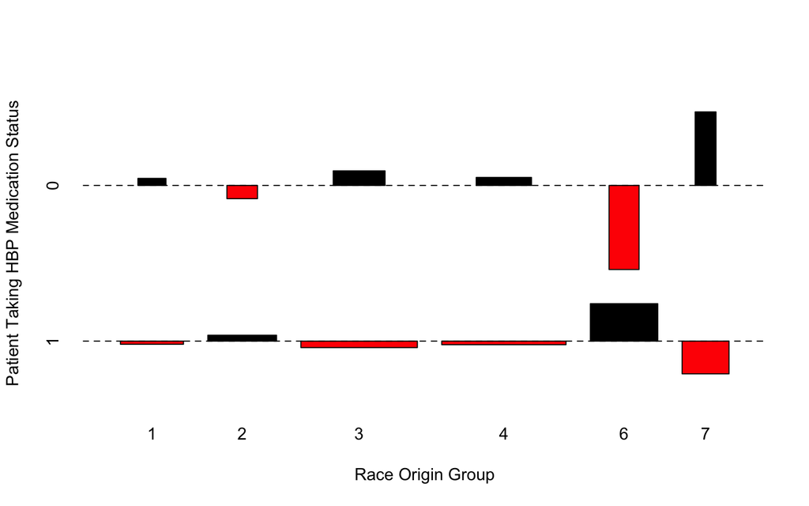

```r
assoc_table <- jk_table
rownames(assoc_table) = c("1", "2", "3", "4", "6", "7")
colnames(assoc_table) = c("0", "1")

assocplot(assoc_table, xlab = 'Race Origin Group',
          ylab = 'Patient Taking HBP Medication Status')
```

Using the *assocplot* function, we can see the deviations from the assumption of independence of rows and columns in our table. We can see that for groups 1-4, the observed values of `bpq050a_e` are very close to the expected value, while groups 6 and 7 are a bit different.

```r
# get absolute values of differences between observed and expected values

jk_matrix <- as.data.frame.matrix(jk_table)

diff_values <- list()
for(rowIndex in 1:6) {
  for(colIndex in 1:2) {
    observedVal <- jk_matrix[rowIndex, colIndex]
    expectedVal <- expected[rowIndex, colIndex + 1]
    difference <- expectedVal - observedVal
    diff_values <- append(diff_values, difference)
  }
}

diff_matrix <- matrix(diff_values, ncol = 2, nrow = 6, byrow = TRUE)
rownames(diff_matrix) <- c(1, 2, 3, 4, 6, 7)
colnames(diff_matrix) <- c(0, 1)

row_names <- c("Mexican American",
               "Other Hispanic",
               "Non-Hispanic White",
               "Non-Hispanic Black",
               "Non-Hispanic Asian",
               "Other Race")

col_names <- c("Not Taking HBP Medication",
               "Taking HBP Medication")

rownames(diff_matrix) = row_names
colnames(diff_matrix) = col_names

diff_matrix
```

```
                   Not Taking HBP Medication Taking HBP Medication
Mexican American   -0.4824281                0.4824281
Other Hispanic     0.9896166                 -0.9896166
Non-Hispanic White -1.841853                 1.841853
Non-Hispanic Black -1.079073                 1.079073
Non-Hispanic Asian 6.162939                  -6.162939
Other Race         -3.749201                 3.749201
```

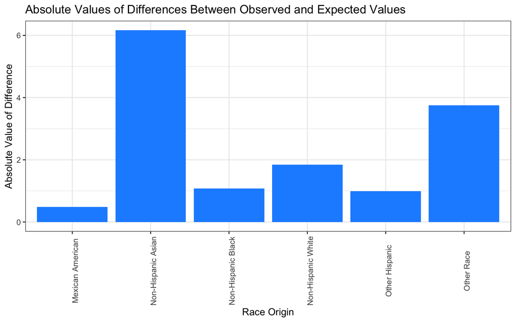

```r
abs_diff <- abs(as.double(diff_values[seq(1, length(diff_values), 2)]))

abs_diff <- as.data.frame(abs_diff)

ggplot(abs_diff, aes(row_names, abs_diff)) +
  geom_bar(stat = "identity", fill = 'Dodger Blue') +
  labs(title = "Absolute Values of Differences Between Observed and Expected Values",
       y = "Absolute Value of Difference",
       x = "Race Origin") +
  theme(axis.text.x = element_text(angle = 90))
```

To reinforce this, we created a bar chart that visualizes the absolute value of differences between the observed and expected values for each group. In doing so, we can see the raw values in terms how different these values are, which in reality isn’t very much, even for groups Non-Hispanic Asian and Other Race.

## 7.4 Conclusions

In this analysis, we looked at the association between a patient’s race origin and whether or not they are taking prescribed medication for high blood pressure. With the data that we had, we used a Pearson’s $\chi^2$ test where we got a p-value of 0.5573. This indicates that we can’t reject the null hypothesis that the distribution of `bpq050a_e` are the same for race origin groups, as the p-value is above our 90% confidence threshold of 0.10. This means that that the rows and columns of the table are independent, so we can conclude that a patient’s race origin isn’t associated with whether or not they are taking prescribed medication for high blood pressure. Furthermore, when we looked at the difference between expected and observed values of each race origin group, the largest difference was only 6.16, which means that for each cell, the observed value was nearly the same as the expected value.